# Flights

## by Tatiana Bibikova

I'm going to explore the flights datasets.

```python
# import all packages and set plots to be embedded inline
import numpy as np
import pandas as pd
import matplotlib.pyplot as plt
import seaborn as sb
import calendar as cd
import matplotlib.dates as mdates

%matplotlib inline
```

#### My interest in exploring these dataset is to find out what are the characteristics of the cancelled flights. I would also like to check if it is changing over a years but I will start with couple of dataset as a sample and then will arrange a dataset from all the avaliable sets in the period from 1987 to 2008.

```python
#loading datasets
sample_1 = pd.read_csv('1990.csv')
sample_2 = pd.read_csv('2008.csv')
```

```python
sample_1.shape[0]
```

```
5270893
```

```python
sample_1.info()
```

```
<class 'pandas.core.frame.DataFrame'>
RangeIndex: 5270893 entries, 0 to 5270892
Data columns (total 29 columns):
Year                 int64
Month                int64
DayofMonth           int64
DayOfWeek            int64
DepTime              float64
CRSDepTime           int64
ArrTime              float64
CRSArrTime           int64
UniqueCarrier        object
FlightNum            int64
TailNum              float64
ActualElapsedTime    float64
CRSElapsedTime       int64
AirTime              float64
ArrDelay             float64
DepDelay             float64
Origin               object
Dest                 object
Distance             float64
TaxiIn               float64
TaxiOut              float64
Cancelled            int64
CancellationCode     float64
Diverted             int64
CarrierDelay         float64
WeatherDelay         float64
NASDelay             float64
SecurityDelay        float64
LateAircraftDelay    float64
dtypes: float64(16), int64(10), object(3)
memory usage: 1.1+ GB
```

```python
sample_2.info()
```

```
<class 'pandas.core.frame.DataFrame'>
RangeIndex: 7009728 entries, 0 to 7009727
Data columns (total 29 columns):
Year                 int64
Month                int64
DayofMonth           int64
DayOfWeek            int64
DepTime              float64
CRSDepTime           int64
ArrTime              float64
CRSArrTime           int64
UniqueCarrier        object
FlightNum            int64
TailNum              object
ActualElapsedTime    float64
CRSElapsedTime       float64
AirTime              float64
ArrDelay             float64
DepDelay             float64
Origin               object
Dest                 object
Distance             int64
TaxiIn               float64
TaxiOut              float64
Cancelled            int64
CancellationCode     object
Diverted             int64
CarrierDelay         float64
WeatherDelay         float64
NASDelay             float64
SecurityDelay        float64
LateAircraftDelay    float64
dtypes: float64(14), int64(10), object(5)
memory usage: 1.5+ GB
```

```python
sample_1.CancellationCode.describe() # apparently 1990 doesn't have info about cancellation
                                     # reassons
```

```
count    0.0
mean     NaN
std      NaN
min      NaN
25%      NaN
50%      NaN
75%      NaN
max      NaN
Name: CancellationCode, dtype: float64
```

```python
sample_2.CancellationCode.describe()# but 2008 has, so we can have a look at it as well
```

```
count     137434
unique         4
top            B
freq       54904
Name: CancellationCode, dtype: object
```

#### for investigating cancelled flight, we only leave those which were cancelled

```python
cancel_1 = sample_1.query('Cancelled == 1')
```

```python
cancel_2 = sample_2.query('Cancelled == 1')
```

```python
# now we will drop columns which do not provide useful information for cancelled flights
column_list = ['DepTime', 'ArrTime', 'TailNum', 'AirTime', 'ArrDelay', 'DepDelay', 'ActualElapsedTime', 'TaxiIn', 'TaxiOut', 'WeatherDelay', 'CarrierDelay', 'NASDelay', 'SecurityDelay', 'LateAircraftDelay', 'Cancelled', 'Diverted' ]
```

```python
cancel_1 = cancel_1.drop(columns = column_list)
cancel_2 = cancel_2.drop(columns = column_list)
```

```python
cancel_1.sample() # just checking that columns are gone
```

|  | Year | Month | DayofMonth | DayOfWeek | CRSDepTime | CRSArrTime | UniqueCarrier | FlightNum | CRSElapsedTime | Origin | Dest | Distance | CancellationCode |
| --- | --- | --- | --- | --- | --- | --- | --- | --- | --- | --- | --- | --- | --- |
| 3124052 | 1990 | 8 | 27 | 1 | 1600 | 1659 | US | 1644 | 59 | BWI | JFK | 184.0 | NaN |

```python
cancel_1.CRSDepTime.min()
```

```
1
```

```python
cancel_1.CRSDepTime.max()
```

```
2359
```

#### time column isn't in a right time format however it will allow us to print histograms and with right ticks can actually be quite helpfull

```python
#checking how the carriers and airports dataset look like
carriers = pd.read_csv('carriers.csv')
airports = pd.read_csv('airports.csv')
```

```python
carriers.sample()
```

|  | Code | Description |
| --- | --- | --- |
| 1034 | PVA | Precision Valley Aviation |

```python
airports.sample()
```

|  | iata | airport | city | state | country | lat | long |
| --- | --- | --- | --- | --- | --- | --- | --- |
| 1374 | EHA | Elkhart-Morton County | Elkhart | KS | USA | 37.001882 | -101.882126 |

```python
country_list = list(airports.country.unique())
country_list
```

```
['USA',
 'Thailand',
 'Palau',
 'N Mariana Islands',
 'Federated States of Micronesia']
```

#### apparently we have information about aiports outside US so we will drop those rows to look at specifically US locations

```python
country_list.remove('USA') #removing USA from the list of the countries
country_list
```

```
['Thailand', 'Palau', 'N Mariana Islands', 'Federated States of Micronesia']
```

```python
#getting abbreviations list from the dataset for the airports in countries
#rather than US

non_US = []
for name in country_list:
    non_US.append(airports.groupby('country').get_group(name).iata.values[0])
```

```python
list(non_US)
```

```
['ROP', 'ROR', 'SPN', 'YAP']
```

```python
count = 0
for name in non_US:
    count = count + cancel_1.query('Origin == @name').shape[0] + cancel_1.query('Origin == @name').shape[0]
count
```

```
178
```

```python
for name in non_US:
    cancel_1 = cancel_1.drop(cancel_1[cancel_1['Origin'] == name].index)
    cancel_2 = cancel_2.drop(cancel_2[cancel_2['Origin'] == name].index)
    cancel_1 = cancel_1.drop(cancel_1[cancel_1['Dest'] == name].index)
    cancel_2 = cancel_2.drop(cancel_2[cancel_2['Dest'] == name].index)
```

```python
cancel_2.query('Origin == "SPN"').shape[0]
```

```
0
```

```python
cancel_1.query('Dest == "ROP"').shape[0]
```

```
0
```

## Univariate Exploration

As the name of the section states, I'm going to check if there any relation between cancelled flight and variables we have in the dataset, i.e. day of the week, day of the months, month, time, destination, origin, etc

##### Let's see what is the most common reason of cancellation

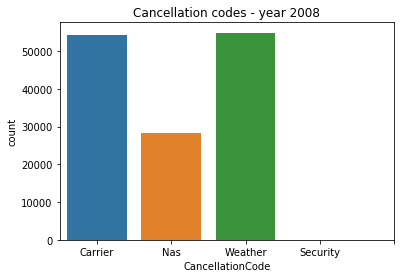

```python
code = ['Carrier', 'Nas', 'Weather', 'Security']
ticks_loc = np.arange(0, 5, 1)
sb.countplot(data = cancel_2, x = 'CancellationCode'); #1987 dataset has no info
plt.xticks(ticks_loc, code);
plt.title('Cancellation codes - year 2008');
```

##### most common reasons for cancellation are carrier and weather, while there are only 12 cases of security cancellation which makes it 0.008% of cases (at least in 2008)

```python
base_color_1 = sb.color_palette()[0]
base_color_2 = sb.color_palette()[1]
```

#### how day of the week and month affects cancellation

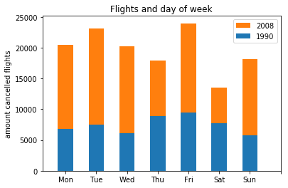

```python
bins = np.arange(0, 8, 0.5)
ticks_loc = np.arange(1.25, 8.5, 1)
weekday = cd.day_abbr[0:8]


plt.hist(data = cancel_2, x = 'DayOfWeek', color = base_color_2,  bins  = bins);
plt.xlim([0.5, 8]);
plt.xticks(ticks_loc, weekday);
plt.ylabel('amount cancelled flights');


plt.hist(data = cancel_1, x = 'DayOfWeek', color = base_color_1,  bins  = bins);
plt.xlim([0.5, 8]);
plt.xticks(ticks_loc, weekday);
plt.ylabel('amount cancelled flights');

plt.title('Flights and day of week');
plt.legend( ['2008', '1990'])
plt.show()
```

#### fridays remain the day of the week with wth most cancelled flights both in 1990 and 2008, while there are more cancelled flights on sundays in comparison to saturdays in 2008 than in 1990. will be interesting to have a look at the trend through the years

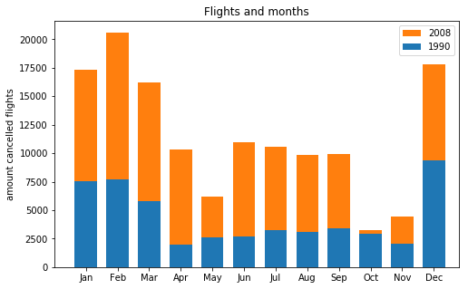

```python
bins = np.arange(0.5, 12.5+1, 1)
ticks_loc = np.arange(1, 12+1, 1)
months = cd.month_abbr[1:13]

plt.figure(figsize = [8, 5])


plt.hist(data = cancel_2, x = 'Month', bins  = bins, rwidth = 0.7, color = base_color_2);
plt.xlim([0, 12.8]);
plt.xticks(ticks_loc, months );
plt.ylabel('amount cancelled flights');


plt.hist(data = cancel_1, x = 'Month', bins  = bins, rwidth = 0.7, color = base_color_1);
plt.xlim([0, 12.8]);
plt.xticks(ticks_loc, months );
plt.ylabel('amount cancelled flights');

plt.legend( ['2008', '1990'])
plt.title('Flights and months')
plt.show()
```

##### winter months seem to be leading in amount of cancelled flight which is probably connected to the weather. makes sense to check this in bivariate plots

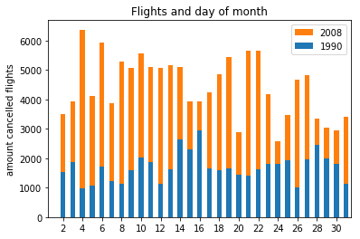

```python
bins = np.arange(1.25, 32.5, 0.5)
ticks_loc = np.arange(2, 32, 2)

plt.hist(data = cancel_2, x = 'DayofMonth', color = base_color_2, bins = bins);
plt.xlim([0.5, 31.5]);
plt.xticks(ticks_loc);
plt.ylabel('amount cancelled flights');

plt.hist(data = cancel_1, x = 'DayofMonth', color = base_color_1, bins = bins);
plt.xlim([0.5, 31.5]);
plt.xticks(ticks_loc);
plt.ylabel('amount cancelled flights');

plt.legend( ['2008', '1990'])
plt.title('Flights and day of month')
plt.show()
```

##### doesn't look like there is a clear tendency when it comes to day of the month

#### now let's check departure time, or, to be precise, scheduled depature time (as obviously cancelled flights never had one)

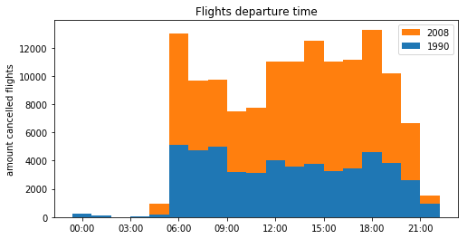

```python
plt.figure(figsize = [8, 4])

bins = np.arange(0, 2400, 120)
ticks_loc = np.arange(60, 2430, 300)
xticks = ['00:00', '03:00', '06:00', '09:00', '12:00', '15:00', '18:00', '21:00','00:00']

plt.hist(data = cancel_2, x = 'CRSDepTime', bins = bins, color = base_color_2);
plt.xticks(ticks_loc, xticks);
plt.ylabel('amount cancelled flights')

plt.hist(data = cancel_1, x = 'CRSDepTime', bins = bins, color = base_color_1);
plt.xticks(ticks_loc, xticks);
plt.ylabel('amount cancelled flights')

plt.legend(['2008', '1990'])
plt.title('Flights departure time')
plt.show()
```

#### seems like there are more cancelled flights in the early morning, around noon and at 6pm

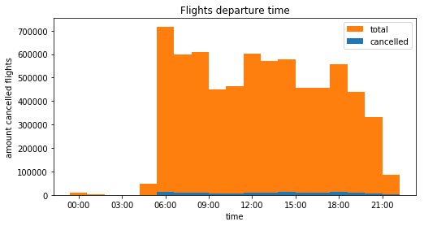

```python
plt.figure(figsize = [8, 4])

bins = np.arange(0, 2400, 120)
ticks_loc = np.arange(60, 2430, 300)
xticks = ['00:00', '03:00', '06:00', '09:00', '12:00', '15:00', '18:00', '21:00','00:00']

plt.hist(data = sample_2, x = 'CRSDepTime', bins = bins, color = base_color_2);
plt.xticks(ticks_loc, xticks);
plt.ylabel('amount cancelled flights')

plt.hist(data = cancel_2, x = 'CRSDepTime', bins = bins, color = base_color_1);
plt.xticks(ticks_loc, xticks);
plt.xlabel('time')
plt.title('Flights departure time')
plt.legend(['total', 'cancelled'])
plt.show()
```

#### but if we look at total amount of fligths we can see that the total amount is also higher in those particular hours and in comparison the distribution looks pretty similar , which means time of the day doesn't seem to affect cancellation

#### as we can't plot histogram with NaN values and there are entries which don't have information about distance, we get to handle it somehow

```python
cancel_1.Distance.isnull().sum()
```

```
1144
```

```python
# 1144 is not even 1% of the information, we drop it
# to get visualisaton of distance
cancel_1_d = cancel_1.dropna(subset = ['Distance'])
cancel_1_d.Distance.isnull().sum()
```

```
0
```

```python
cancel_2.Distance.isnull().sum()
```

```
0
```

#### now we will check if there is any connection between distance and cancellation, i.e. if there are more cancelled flight for longer distances, for example

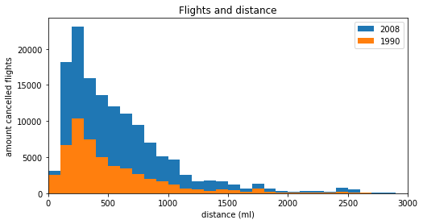

```python
binsize = 100
plt.figure(figsize = [8,4])

bins_2 = np.arange(0, cancel_2['Distance'].max()+binsize, binsize)
plt.hist(data = cancel_2, x = 'Distance', bins = bins_2);
plt.xlim([0,3000]);

bins_1 = np.arange(0, cancel_1_d['Distance'].max()+binsize, binsize)
plt.hist(data = cancel_1_d, x = 'Distance', bins = bins_1);
plt.xlim([0,3000]);


plt.legend(['2008', '1990'])
plt.ylabel('amount cancelled flights')
plt.xlabel('distance (ml)')
plt.title('Flights and distance')
plt.show()
```

#### it might seem that there are more cancelled flights if the distance is shorter

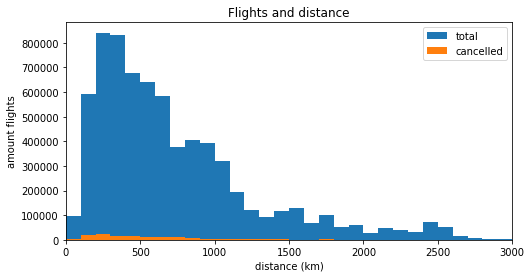

```python
binsize = 100
plt.figure(figsize = [8,4])

bins_3 = np.arange(0, sample_2['Distance'].max()+binsize, binsize)
plt.hist(data = sample_2, x = 'Distance', bins = bins_3)

bins_2 = np.arange(0, cancel_2['Distance'].max()+binsize, binsize)
plt.hist(data = cancel_2, x = 'Distance', bins = bins_2);
plt.xlim([0,3000]);


plt.legend(['total', 'cancelled'])
plt.ylabel('amount flights')
plt.xlabel('distance (km)')
plt.title('Flights and distance')
plt.show()
```

#### however if we print total amount of flights on the same graph we can see that there are just more flights for shorter destination in general, thus there is not reasonable corretaltion based on distance of the fligth

#### now let's have a look if certain carrier have more cancelled flights than others

[figure not shown]

```python
plt.figure(figsize = [14, 4])

plt.subplot(1,2,2)
sb.countplot(data = cancel_2, x = 'UniqueCarrier', order = cancel_2.UniqueCarrier.value_counts().index, color = base_color_2);
plt.title('Cancelled flights per carrier - 1990')

plt.subplot(1,2,1)
sb.countplot(data = cancel_1, x = 'UniqueCarrier', order = cancel_1.UniqueCarrier.value_counts().index, color = base_color_1);
plt.title('Cancelled flights per carrier - 2008')

plt.show()
```

#### by itself these graphs don't provide us enough information - althoug we can see that some carrier have more cancellation, it is different amount of carriers in 1990 and 2008 datasets and without comparison with total amount of flights per carrier it is hard to make any conclusion

```python
#creatint the list of carriers in each dataset
list_1 = list(cancel_1.UniqueCarrier.unique())
list_2 = list(cancel_2.UniqueCarrier.unique())
```

```python
#make a list of carriers which present in both years
match_cr = list(set(list_1)&set(list_2))
```

```python
#leaving those carriers in both datasets for cancelled and total amount of flights
cancel_1a = cancel_1[cancel_1['UniqueCarrier'].isin(match_cr)]
cancel_2a = cancel_2[cancel_2['UniqueCarrier'].isin(match_cr)]
sample_1a = sample_1[sample_1['UniqueCarrier'].isin(match_cr)]
sample_2a = sample_2[sample_2['UniqueCarrier'].isin(match_cr)]
```

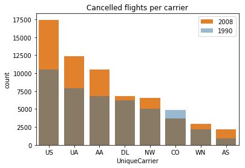

```python
sb.countplot(data = cancel_2a, x = 'UniqueCarrier', order = cancel_2a.UniqueCarrier.value_counts().index, color = base_color_2);
sb.countplot(data = cancel_1a, x = 'UniqueCarrier', order = cancel_1a.UniqueCarrier.value_counts().index, alpha = 1/2, color = base_color_1);
plt.legend(['2008', '1990'])
plt.title('Cancelled flights per carrier')
plt.show()
```

##### on this graph we can see how the absolut amount of cancellations changed from 1990 to 2008; now let's look at percentage:

```python
# calculating percentage of cancelled fligths for each dataset
cancel_1_per = cancel_1a.UniqueCarrier.value_counts()/sample_1a.UniqueCarrier.value_counts()*100
cancel_2_per = cancel_2a.UniqueCarrier.value_counts()/sample_2a.UniqueCarrier.value_counts()*100
```

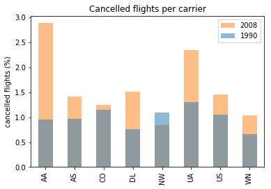

```python
cancel_2_per.plot(kind = 'bar', color = base_color_2, alpha = 1/2);
cancel_1_per.plot(kind = 'bar', color = base_color_1, alpha = 1/2);

plt.ylabel('cancelled flights (%)')
plt.title('Cancelled flights per carrier')

plt.legend(['2008', '1990'])
plt.show()
```

#### after doing the calculations for the proportions we can see that for 7 out of 8 companies percentage of cancellations grew, however, in different degree. generally we are talking about amount between under 1% as minimum and under 4% as maximum. amount of cancelled flights per carrier seems to be growing

```python
carriers.query('Code == "AA"')
```

|  | Code | Description |
| --- | --- | --- |
| 100 | AA | American Airlines Inc. |

```python
carriers.query('Code == "UA"')
```

|  | Code | Description |
| --- | --- | --- |
| 1297 | UA | United Air Lines Inc. |

#### next exploration variable - origin of the flight, are there more cancelled flights from specific origins?

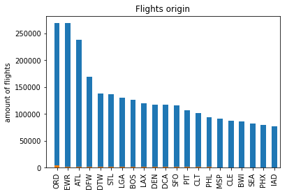

```python
sample_1['Origin'].value_counts().plot(kind="bar", color = base_color_1)
cancel_1['Origin'].value_counts().plot(kind="bar", color = base_color_2)

plt.xlim([-1, 20.5])#only plot the first 20 origins

plt.title('Flights origin')
plt.ylabel('amount of flights')
plt.show();
```

##### doesnt' look like a best visualisation, need to try subplot to see if the origin comes in the same order

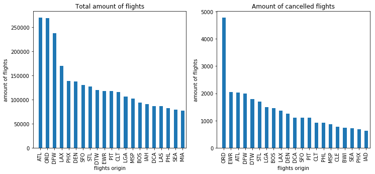

```python
plt.figure(figsize = [12, 5])

plt.subplot (1,2,1)
sample_1['Origin'].value_counts().plot(kind="bar", color = base_color_1)
plt.xlim([-1, 20.5])#only plot the first 20 origins
plt.title('Total amount of flights')
plt.ylabel('amount of flights')
plt.xlabel('flights origin')

plt.subplot(1,2,2)
cancel_1['Origin'].value_counts().plot(kind="bar", color = base_color_1)
plt.xlim([-1, 20.5])#only plot the first 20 origins
plt.title('Amount of cancelled flights')
plt.ylabel('amount of flights')
plt.xlabel('flights origin')

plt.show();
```

##### as origins do not come in the same order, i.e. the higest amount of cancelled flights isn't in the origin with highest total amount of flights, it means that origin does affect amount of cancellations. let'slook at origins in percentage:

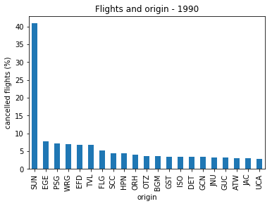

```python
cancelled_per_o = cancel_1.Origin.value_counts()/sample_1.Origin.value_counts()*100

cancelled_per_o.sort_values(ascending=False).plot(kind = 'bar', color = base_color_1);
plt.xlim([-0.5, 20.5]); #as there are many origins we will only look at the origins with higher percentage
plt.title('Flights and origin - 1990')
plt.ylabel('cancelled flights (%)')
plt.xlabel('origin');
```

#### we can see that origins which appear in the graphs for absolut amount do not appear in the first 20 with highest amount of cancellation

#### going to get some additional information about origins with high percentage of cancellations

```python
sample_1.query('Origin == "SUN"').Origin.value_counts()
```

```
SUN    66
Name: Origin, dtype: int64
```

```python
cancel_1.query('Origin == "SUN"').Origin.value_counts()
```

```
SUN    27
Name: Origin, dtype: int64
```

```python
airports.query('iata == "SUN"')
```

|  | iata | airport | city | state | country | lat | long |
| --- | --- | --- | --- | --- | --- | --- | --- |
| 3028 | SUN | Friedman Memorial | Hailey | ID | USA | 43.504841 | -114.29659 |

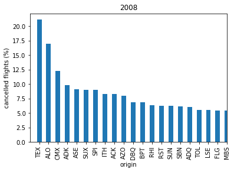

```python
cancelled_per_2 = cancel_2.Origin.value_counts()/sample_2.Origin.value_counts()*100

cancelled_per_2.sort_values(ascending=False).plot(kind = 'bar', color = base_color_1);
plt.xlim([-1, 20]);
plt.title('2008')
plt.ylabel('cancelled flights (%)')
plt.xlabel('origin');
```

#### in 2008 the origin with highest percentage of cancellation is different compare to 1990, so we have a closer look at it

```python
sample_2.query('Origin == "TEX"').Origin.value_counts()
```

```
TEX    194
Name: Origin, dtype: int64
```

```python
cancel_2.query('Origin == "TEX"').Origin.value_counts()
```

```
TEX    41
Name: Origin, dtype: int64
```

```python
airports.query('iata == "TEX"')
```

|  | iata | airport | city | state | country | lat | long |
| --- | --- | --- | --- | --- | --- | --- | --- |
| 3096 | TEX | Telluride Regional | Telluride | CO | USA | 37.953759 | -107.90848 |

##### if we plot percentage of cancelled flights, we can see that SUN is on the leading position with more that 40% cancellation in 1990, and in 2008 it's TEX which is on the firts place.

##### if to pay attention to the fact that none of those origins appear in the first 20 (by the amount of cancelled fligths) origins, one would wonder how can this happend. and it actually can because it is the procentage and thus small total amount of flights can lead to higher percentage of cancellation. so general conclusion that the size of the airport might affect amount of cancelled flights

```python
sample_1.query('Origin == "TEX"').Origin.value_counts()
```

```
Series([], Name: Origin, dtype: int64)
```

#### that fact might mean two things - either Telluride Regional flights weren't counted or Telluride Regional airport hasn't been opened by that time yet. that in its turn might mean that new airport have higher amount of cancelled flights

```python
sample_2.query('Origin == "SUN"').Origin.value_counts()
```

```
SUN    2871
Name: Origin, dtype: int64
```

```python
cancel_2.query('Origin == "SUN"').Origin.value_counts()
```

```
SUN    179
Name: Origin, dtype: int64
```

#### we do some simple filtering and calculations to see if there is any relation

```python
amount = sample_1['Origin'].value_counts()
condition = amount<1456  #that would be 28 flights a week/ 4 flights a day
mask = amount[condition].index
```

```python
per_cancelled = cancelled_per_o.sort_values()
condition = per_cancelled> 3 # cancellation more than 3%
mask_2 = per_cancelled[condition].index
```

```python
#amount of matching origins - low amount of flights and high percentage of cancellations
match = len(list(set(mask)&set(mask_2)))
```

```python
print('amount of origins with less than 1456 flights per year:', len(mask))
print('amount of origins with more than 3% cancelled flight:', len(mask_2))
print('amount matching origins:', match)
```

```
amount of origins with less than 1456 flights per year: 50
amount of origins with more than 3% cancelled flight: 19
amount matching origins: 13
```

```python
amount = sample_1['Origin'].value_counts()
condition = amount >50000  # origins with more than 50000 flights a year
mask = amount[condition].index
```

```python
per_cancelled = cancelled_per_o.sort_values()
condition = per_cancelled>1.5 #origins with amount of cancellation under 1.5%
mask_2 = per_cancelled[condition].index
```

```python
#amount of matching origins - high amount of flights and low percentage of cancellations
match = len(list(set(mask)&set(mask_2)))
```

```python
print('amount of origins with more than 50000 flights per year:', len(mask))
print('amount of origins with more than 1.5% cancelled flight:', len(mask_2))
print('amount matching origins:', match)
```

```
amount of origins with more than 50000 flights per year: 33
amount of origins with more than 1.5% cancelled flight: 76
amount matching origins: 3
```

##### the conclusion we can draw is that origins with small amount of flights have higher percentage of cancellation

#### last variable to check - destination, if for some reasons flights are being cancelled to certaion destinations more often

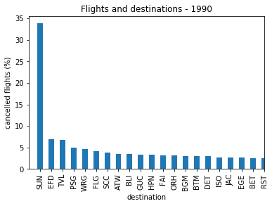

```python
cancelled_per_d = cancel_1.Dest.value_counts()/sample_1.Dest.value_counts()*100

cancelled_per_d.sort_values(ascending=False).plot(kind = 'bar', color = base_color_1);
plt.xlim([-1, 20]);
plt.title('Flights and destinations - 1990')
plt.ylabel('cancelled flights (%)')
plt.xlabel('destination');
```

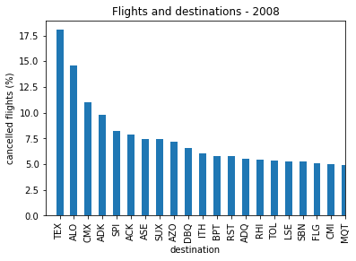

```python
cancelled_per_d2 = cancel_2.Dest.value_counts()/sample_2.Dest.value_counts()*100

cancelled_per_d2.sort_values(ascending=False).plot(kind = 'bar', color = base_color_1);
plt.xlim([-1, 20]);
plt.title('Flights and destinations - 2008')
plt.ylabel('cancelled flights (%)')
plt.xlabel('destination');
```

#### with the destination we see similar correlation as with origin

#### From univariate exploration and comparison of two years we can see some relations. fligths often being cancelled because if weather and there more during winter time.

#### day of the month or time of the days don't show any specific tendency as well as lenght of the flight. however size of the aiport and the time it's been operating might be a valid reason for higher amount of cancelled flights.

#### I adjusted initial datasets as my partuclar point of interest were cancelled flights so I removed unrelated information.

#### To be able to pring some histograms I got to delete entries with NaN values, however it was very low amount whihc won't affect the whole picture.

#### In some cases I got to calculate proportion as absolute amount wouldn't be representative enough.

## Bivariate Exploration

#### as we've seen in univariate exploration, winter months have higher amount of cancellation, so we start at looking at those two variables - cause of cancellation and month

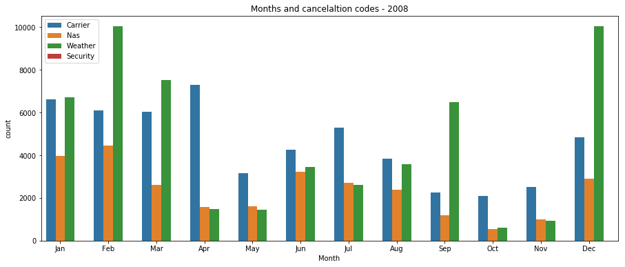

```python
plt.figure(figsize = [15, 6])
#bins = np.arange(0.5, 12.5+1, 1)
ticks_loc = np.arange(-0.1, 11.9, 1)
months = cd.month_abbr[1:13]
sb.countplot(data = cancel_2, x = 'Month', hue = 'CancellationCode');
code = ['Carrier', 'Nas', 'Weather', 'Security']
plt.xticks(ticks_loc, months)
plt.legend(code, loc='best');
plt.title('Months and cancelaltion codes - 2008');
```

#### as we can see on the graph weather is the leading cancellation reason in winter months which makes sence. that also means that origins with more distinct seasonal differences will have higher cancellation percentage

#### so we check the origin and cancellation code relations

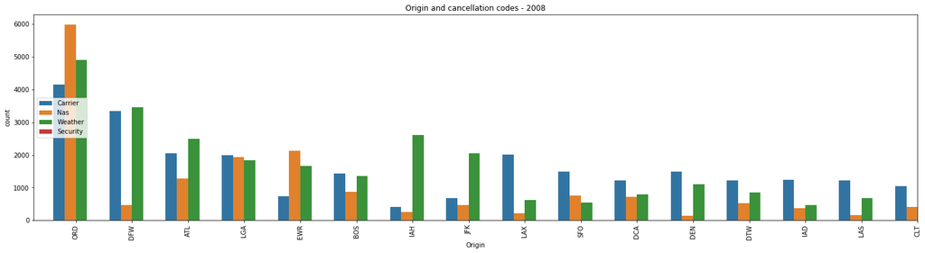

```python
plt.figure(figsize = [25, 6])
sb.countplot(data = cancel_2, x = 'Origin', hue = 'CancellationCode', order = cancel_2.Origin.value_counts().index);
code = ['Carrier', 'Nas', 'Weather', 'Security']
plt.xticks(rotation = 90)
plt.legend(code, loc=6);
plt.title('Origin and cancellation codes - 2008');
plt.xlim([-0.75,15]);
```

#### get some data about origins for which NAS is the most common cancellation reason

```python
airports.query('iata == "ORD"')
```

|  | iata | airport | city | state | country | lat | long |
| --- | --- | --- | --- | --- | --- | --- | --- |
| 2531 | ORD | Chicago O'Hare International | Chicago | IL | USA | 41.979595 | -87.904464 |

```python
airports.query('iata == "EWR"')
```

|  | iata | airport | city | state | country | lat | long |
| --- | --- | --- | --- | --- | --- | --- | --- |
| 1436 | EWR | Newark Intl | Newark | NJ | USA | 40.692497 | -74.168661 |

#### and for Chicago and Newark NAS happens to be the most common cancellation reason in 2008 which probably due to location of the cities being in the border of the country

#### and some data about origins for which weather is the most common reason

```python
airports.query('iata == "DFW"')
```

|  | iata | airport | city | state | country | lat | long |
| --- | --- | --- | --- | --- | --- | --- | --- |
| 1268 | DFW | Dallas-Fort Worth International | Dallas-Fort Worth | TX | USA | 32.895951 | -97.0372 |

```python
airports.query('iata == "IAH"')
```

|  | iata | airport | city | state | country | lat | long |
| --- | --- | --- | --- | --- | --- | --- | --- |
| 1837 | IAH | George Bush Intercontinental | Houston | TX | USA | 29.980472 | -95.339722 |

```python
airports.query('iata == "ATL"')
```

|  | iata | airport | city | state | country | lat | long |
| --- | --- | --- | --- | --- | --- | --- | --- |
| 880 | ATL | William B Hartsfield-Atlanta Intl | Atlanta | GA | USA | 33.640444 | -84.426944 |

```python
airports.query('iata == "JFK"')
```

|  | iata | airport | city | state | country | lat | long |
| --- | --- | --- | --- | --- | --- | --- | --- |
| 1915 | JFK | John F Kennedy Intl | New York | NY | USA | 40.639751 | -73.778926 |

#### so as we can see there are indeed more cancellation in relation to weather in certain regions like Texas

#### let's see if there are similar relations for destinations

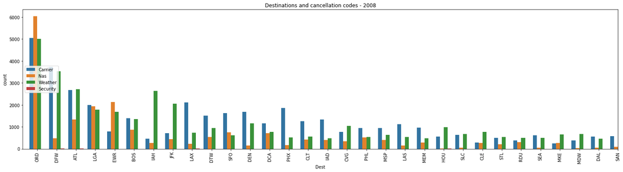

```python
plt.figure(figsize = [25, 6])
sb.countplot(data = cancel_2, x = 'Dest', hue = 'CancellationCode', order = cancel_2.Dest.value_counts().index);
code = ['Carrier', 'Nas', 'Weather', 'Security']
plt.xticks(rotation = 90)
plt.legend(code, loc=6);
plt.title('Destinations and cancellation codes - 2008');
plt.xlim([-0.75,30]);
```

#### as well as for origin, Chicago airport has highest amount of cancellation due to NAS

#### and now we check how does relation of carrier and cancellation reason look like

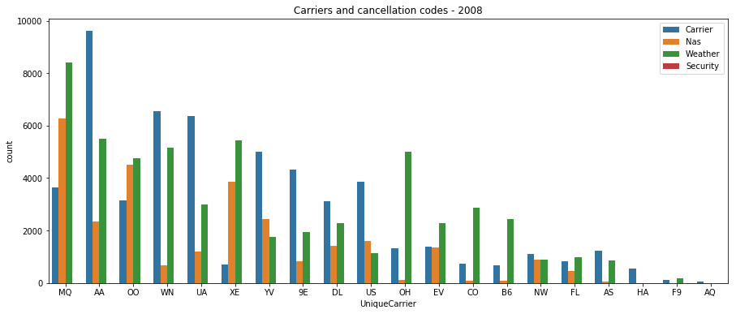

```python
plt.figure(figsize = [15, 6])
sb.countplot(data = cancel_2, x = 'UniqueCarrier', hue = 'CancellationCode', order = cancel_2.UniqueCarrier.value_counts().index);
plt.legend(code, loc='upper right');
plt.title('Carriers and cancellation codes - 2008');
```

#### for some carriers weather appears more common reason while for others carrier itslef is responsible. OH carries has outstanding high amount of cancellation due to weather on comparison to other reasons, CO and B6 have similar distribution but not as high. this might be something worth further investigaton.

```python
carriers.query('Code == "OH"')
```

|  | Code | Description |
| --- | --- | --- |
| 936 | OH | Comair Inc. |

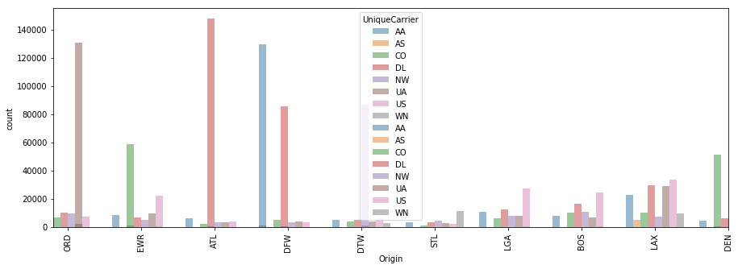

```python
plt.figure(figsize = [15,5])

sb.countplot(data = cancel_1a.sort_values('UniqueCarrier'), x = 'Origin', hue = 'UniqueCarrier', order = cancel_1.Origin.value_counts().index,  palette=["C0", "C1","C2","C3", "C4","C5", "C6", "C7"], alpha = 1/2)
sb.countplot(data = sample_1a.sort_values('UniqueCarrier'), x = 'Origin', hue = 'UniqueCarrier', order = cancel_1.Origin.value_counts().index,  palette=["C0", "C1","C2","C3", "C4","C5", "C6", "C7"], alpha = 1/2)
plt.xticks(rotation = 90);
plt.xlim([-0.2, 9]);
```

### I have created new datasets of cancelled flights between 1987 and 2008 and collected data ot total amount of flights during this period (see file get_dataset_function.ipnb)

```python
#loading the dataset
df_can = pd.read_csv('cancelled.csv', low_memory=False)
```

```python
df_can.sample()
```

|  | Unnamed: 0 | index | Year | Month | DayofMonth | DayOfWeek | CRSDepTime | CRSArrTime | UniqueCarrier | FlightNum | CRSElapsedTime | Origin | Dest | Distance | CancellationCode |
| --- | --- | --- | --- | --- | --- | --- | --- | --- | --- | --- | --- | --- | --- | --- | --- |
| 49536 | 49536 | 1905321 | 1988 | 5 | 10 | 2 | 1300 | 1559 | NW | 1204 | 119.0 | MKE | LGA | 738.0 | NaN |

```python
df_can.info()
```

```
<class 'pandas.core.frame.DataFrame'>
RangeIndex: 2303324 entries, 0 to 2303323
Data columns (total 15 columns):
Unnamed: 0          int64
index               int64
Year                int64
Month               int64
DayofMonth          int64
DayOfWeek           int64
CRSDepTime          int64
CRSArrTime          int64
UniqueCarrier       object
FlightNum           int64
CRSElapsedTime      float64
Origin              object
Dest                object
Distance            float64
CancellationCode    object
dtypes: float64(2), int64(9), object(4)
memory usage: 263.6+ MB
```

```python
count = 0 #counting how many flights are done outside the US
for name in non_US:
    count = count + df_can.query('Origin == @name').shape[0]+df_can.query('Dest == @name').shape[0]
count
```

```
932
```

```python
#as we only looking at US, non-Us will be dropped
for name in non_US:
    df_can = df_can.drop(df_can[df_can['Dest'] == name].index)
    df_can = df_can.drop(df_can[df_can['Dest'] == name].index)
```

```python
df_can.query('Dest == "ROP"').shape[0]
```

```
0
```

```python
#loading additional datasets with amount of cancelled flight per year
# per year for carrier and per year for origin
df_amount = pd.read_csv('amount.csv')
df_carrier = pd.read_csv('amount_carrier.csv')
df_origin = pd.read_csv('amount_origin.csv')
```

#### with this data I'll try to check some of the correlations we were exploring for particular years (1990 and 2008) plus see some changes during this period. I only will plot those which look more promissing, i.e. showing some relations, and will skip those which look irrelevant

#### start with cancellation code

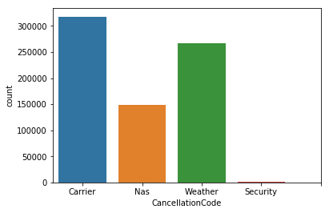

```python
code = ['Carrier', 'Nas', 'Weather', 'Security']
ticks_loc = np.arange(0, 5, 1)
sb.countplot(data = df_can, x = 'CancellationCode');
plt.xticks(ticks_loc, code);
```

#### with data collected within few years carrier appears more frequent cancellation reason, however all the data up to 1990 doesn't have information about it

#### checking day of the week relation

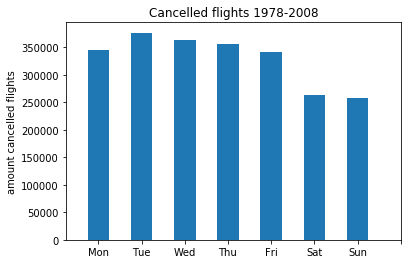

```python
bins = np.arange(0, 8, 0.5)
ticks_loc = np.arange(1.25, 8.5, 1)
weekday = cd.day_abbr[0:8]
plt.hist(data = df_can, x = 'DayOfWeek', bins  = bins);
plt.xlim([0.5, 8]);
plt.xticks(ticks_loc, weekday);
plt.ylabel('amount cancelled flights');
plt.title('Cancelled flights 1978-2008');
```

#### now amount of cancelled flight in relation to week day seems to be more even with weekend having lower amount cancellations

#### and the month

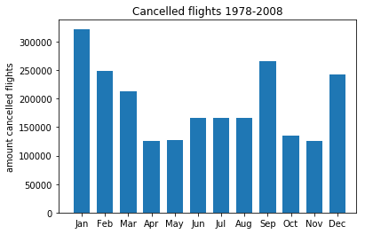

```python
bins = np.arange(0.5, 12.5+1, 1)
ticks_loc = np.arange(1, 12+1, 1)
months = cd.month_abbr[1:13]

plt.hist(data = df_can, x = 'Month', bins  = bins, rwidth = 0.7);
plt.xlim([0, 12.8]);
plt.xticks(ticks_loc, months );
plt.ylabel('amount cancelled flights');
plt.title('Cancelled flights 1978-2008');
```

#### winter months still lead in amount of cancellations; check a bivariate graph as well:

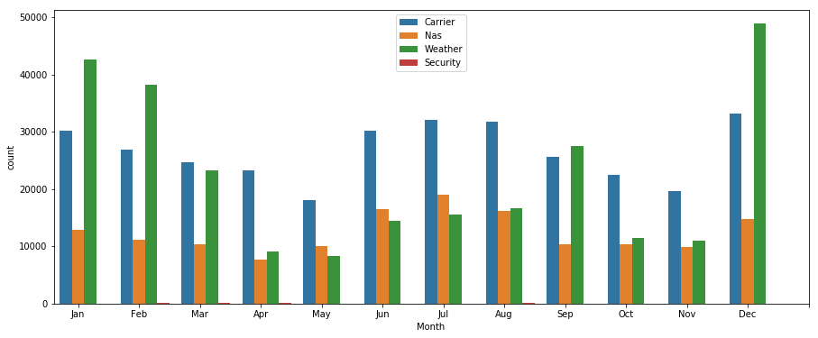

```python
plt.figure(figsize = [15, 6])
#bins = np.arange(0.5, 12.5+1, 1)
ticks_loc = np.arange(-0.1, 12, 1)
months = cd.month_abbr[1:13]
sb.countplot(data = df_can, x = 'Month', hue = 'CancellationCode');
code = ['Carrier', 'Nas', 'Weather', 'Security']
plt.xticks(ticks_loc, months)
plt.legend(code, loc='best');
```

#### weather remains strong cancellation reason as well as more frequently occuring in winter months

#### now I will check the relation between carrier and cancellation - again, for the period of years. for this I'll manipulate data to obtain bits of easy-to-plot data

```python
#get additional information - total amount of flights per carrier for 1987-2008
#as total amount of carriers within given period is higher than amount of carriers with cancelled flights,
#we create a dataset which contains only origins present in both of them

car_list_1 = list(df_carrier.carrier.unique())#list of origins in the dataset with total amount of flights per carrier
car_list_2 = list(df_can.UniqueCarrier.unique())#list of origins in the dataset with cancelled amount of flights per carrier
match = list(set(car_list_1)&set(car_list_2))#getting the list of carriers which present in both datasets

amount_flights = []
for carrier in car_list_1:
    amount_flights.append(df_carrier.query('carrier == @carrier').amount.sum())

#creating a new dataset with origins and cancelled flight per origin
new_df = pd.DataFrame({'carrier': car_list_1, 'total_flights':amount_flights})
```

```python
#filtering carriers according to the matching list
new_df_car = new_df[new_df['carrier'].isin(match)]
```

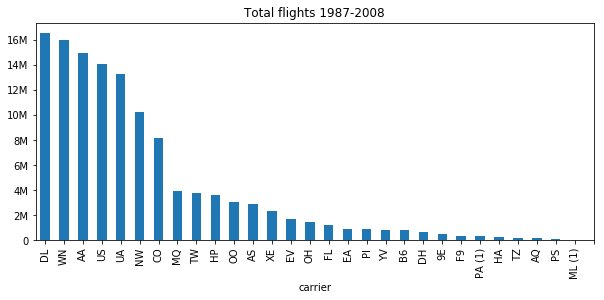

```python
fig, ax = plt.subplots(figsize = [10,4]);
yticks_loc = np.arange(0, new_df_car.total_flights.max(), 2000000)
numbers = ['0', '2M', '4M', '6M', '8M', '10M', '12M', '14M', '16M']
order = list(new_df_car.sort_values("total_flights", ascending = False).carrier)
xticks_loc = np.arange(0, len(match)+0.5, 1)
new_df_car.total_flights.sort_values(ascending = False).plot(kind = 'bar', color = base_color_1);
plt.yticks(yticks_loc, numbers)
plt.xticks(xticks_loc, order)
plt.xlabel('carrier')
plt.title('Total flights 1987-2008');
```

```python
new_index = list(new_df_car.carrier)
num = df_can.UniqueCarrier.value_counts()
num = num.reindex(index = new_index)
new_df_car['percent'] = np.array(num)/new_df_car.total_flights*100
```

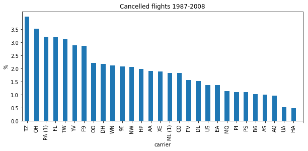

```python
yticks_loc = np.arange(0, new_df_car.percent.max(), 0.5)
xticks_loc = np.arange(0, len(match)+0.5, 1)
fig, ax = plt.subplots(figsize = [10,4]);
new_df_car.percent.sort_values(ascending = False).plot(kind = 'bar', color = base_color_1);
plt.xticks(xticks_loc, match)
plt.yticks(yticks_loc)
plt.ylabel('%')
plt.xlabel('carrier')
plt.title('Cancelled flights 1987-2008');
```

#### what we see in these two graphs is that carriers with a higher a mount of total flights do not appear in the highest percentage of cancellation which means that bigger carriers have lower percentage of cancellations

#### move on to cancellations and origins

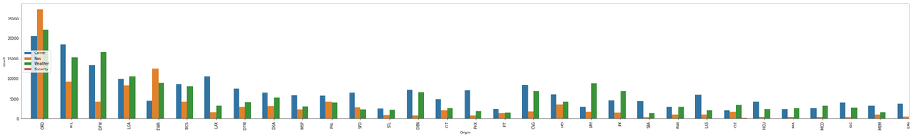

```python
plt.figure(figsize = [45, 6])
sb.countplot(data = df_can, x = 'Origin', hue = 'CancellationCode', order = df_can.Origin.value_counts().index);
code = ['Carrier', 'Nas', 'Weather', 'Security']
plt.xticks(rotation = 90)
plt.legend(code, loc=6);
plt.xlim([-0.75,30]);
```

#### Chicago and Newark hold NAS as it's main cancellation reason within 22 years (worth checking why), for most of the carriers though it is the carrier itself

#### do some filtering and math to see if relations of the size (amount of flights per year) and amount of cancellations still remains within the period of few years rather than within a year:

```python
amount = df_can['Origin'].value_counts()
condition = amount < 1500 #amount of flights less than 1500 p/year
mask = amount[condition].index

per_cancelled = cancelled_per_o.sort_values()
condition = per_cancelled>1.5 #percentage of cancelled flights more than 1.5
mask_2 = per_cancelled[condition].index

match = len(list(set(mask)&set(mask_2)))
```

```python
print('amount of origins with less than 1500 flights per year:', len(mask))
print('amount of origins with more than 1.5% cancelled flight:', len(mask_2))
print('amount matching origins:', match)
```

```
amount of origins with less than 1500 flights per year: 197
amount of origins with more than 1.5% cancelled flight: 76
amount matching origins: 45
```

```python
df_can.Origin.value_counts().max()
```

```
201073
```

```python
amount = df_can['Origin'].value_counts()
condition = amount >50000 #amount of flights more than 50000 p/year
mask = amount[condition].index

per_cancelled = cancelled_per_o.sort_values()
condition = per_cancelled>3 #percentage of cancelled flights more than 3
mask_2 = per_cancelled[condition].index

match = list(set(mask)&set(mask_2))
```

```python
print('amount of origins with more than 50000 flights per year:', len(mask))
print('amount of origins with more than 3% cancelled flight:', len(mask_2))
print('amount matching origins:', len(match))
```

```
amount of origins with more than 50000 flights per year: 12
amount of origins with more than 3% cancelled flight: 19
amount matching origins: 0
```

```python
amount = df_can['Origin'].value_counts()
condition = amount >50000
mask = amount[condition].index

per_cancelled = cancelled_per_o.sort_values()
condition = per_cancelled>1.5
mask_2 = per_cancelled[condition].index

match = list(set(mask)&set(mask_2))
```

```python
print('amount of origins with more than 50000 flights per year:', len(mask))
print('amount of origins with more than 1.5% cancelled flight:', len(mask_2))
print('amount matching origins:', len(match))
```

```
amount of origins with more than 50000 flights per year: 12
amount of origins with more than 1.5% cancelled flight: 76
amount matching origins: 3
```

#### now I'm going to see how the origins and cancellations look in the period of 1978 to 2008 and manipulate the data similar way I did for the carriers.

```python
#as total amount of origins within given period is higher than amount of origins with cancelled flights,
#we create a dataset which contains only origins present in both of them

or_list_1 = list(df_origin.origin.unique()) #list of origins in the dataset with total amount of flights per origin
or_list_2 = list(df_can.Origin.unique()) #list of origins in the dataset with cancelled amount of flights per origin
match_o = list(set(or_list_1)&set(or_list_2)) #getting the list of origins which present in both datasets

amount_flights_2 = []
for origin in or_list_1:
    amount_flights_2.append(df_origin.query('origin == @origin').amount.sum())

#creating a new dataset with origins and cancelled flight per origin
new_df_2 = pd.DataFrame({'origin': or_list_1, 'total_flights':amount_flights_2})
```

```python
#filtering origins according to the matching list
new_df_or = new_df_2[new_df_2['origin'].isin(match_o)]
```

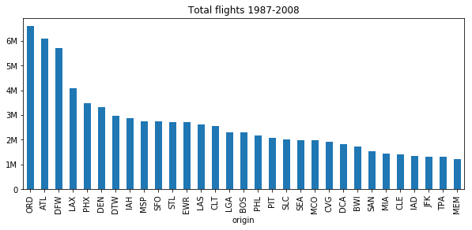

```python
fig, ax = plt.subplots(figsize = [10,4]);
yticks_loc = np.arange(0, new_df_or.total_flights.max(), 1e6)
numbers = ['0', '1M', '2M', '3M', '4M', '5M', '6M', '7M']
order = list(new_df_or.sort_values("total_flights", ascending = False).origin)
xticks_loc = np.arange(0, len(match_o), 1)
new_df_or.total_flights.sort_values(ascending = False).plot(kind = 'bar', color = base_color_1);
plt.yticks(yticks_loc, numbers)
plt.xticks(xticks_loc, order)
plt.xlim([-0.5,30.5])#plotling only 30 biggest origins
plt.xlabel('origin')
plt.title('Total flights 1987-2008');
```

#### so we can see here the amount of flights in the biggest aiports or better say airports with biggest amount of flights

#### I will add percentage of cancelled flights to the dataset with total number of flights

```python
#to match the order of the origins
new_index = list(new_df_or.origin)
num = df_can.Origin.value_counts()
num = num.reindex(index = new_index)
new_df_or['percent'] = np.array(num)/new_df_or.total_flights*100
```

```python
#drop origins with less than 5 flights a year as an outlier
new_df_or = new_df_or.drop(new_df_or[new_df_or.total_flights < 5].index)
```

```python
#drop origins with less than 1500 flights a year
few_flights_or = new_df_or.drop(new_df_or[new_df_or.total_flights > 1500].index)
```

#### I want to have a look at the origins with low amount of flights and with a high amounts of flights to see how the percentage of cancellation looks like

[figure not shown]

```python
yticks_loc = np.arange(0, few_flights_or.percent.max(),2)
xticks_loc = np.arange(0, few_flights_or.shape[0], 1)
fig, ax = plt.subplots(figsize = [10,4]);
few_flights_or.percent.sort_values(ascending = False).plot(kind = 'bar', color = base_color_1);
plt.xticks(xticks_loc, match_o)
plt.yticks(yticks_loc)
plt.ylabel('%')
plt.xlabel('origin')
#plt.xlim([-0.7,30.5])
plt.title('Cancelled flights 1987-2008 for small airports (>1500 fl/y)');
```

```python
#filtering the airports with more than 50000 flight per year:
many_flight_or = new_df_or.drop(new_df_or[new_df_or.total_flights < 50000].index)
```

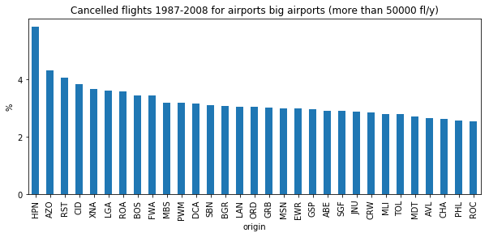

```python
yticks_loc = np.arange(0, many_flight_or.percent.max(),2)
xticks_loc = np.arange(0, many_flight_or.origin.nunique(), 1)
xticks = list(many_flight_or.sort_values('percent', ascending = False).origin)
fig, ax = plt.subplots(figsize = [10,4]);
many_flight_or.percent.sort_values(ascending = False).plot(kind = 'bar', color = base_color_1);
plt.xticks(xticks_loc, xticks)
plt.yticks(yticks_loc)
plt.ylabel('%')
plt.xlabel('origin')
plt.xlim([-0.5,30.5]) #30 first of airports from the list of airport with high amount of flights
plt.title('Cancelled flights 1987-2008 for airports big airports (more than 50000 fl/y)');
```

#### for the large airports percentage of cancellations is lower and more even

#### and statistically

```python
few_flights_or.percent.describe()
```

```
count    26.000000
mean      4.762069
std       3.563645
min       0.452489
25%       1.537853
50%       4.041372
75%       7.565778
max      15.519766
Name: percent, dtype: float64
```

```python
many_flight_or.percent.describe()
```

```
count    161.000000
mean       1.956884
std        0.804699
min        0.683277
25%        1.319897
50%        1.884132
75%        2.350076
max        5.839841
Name: percent, dtype: float64
```

#### so what we see is the average percentage of cancellation for small airports in more than 2 times higher

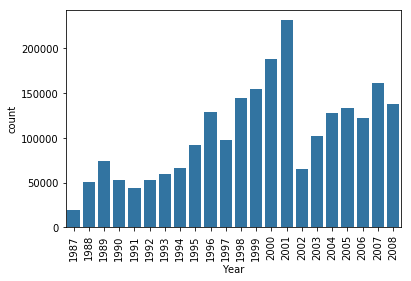

```python
sb.countplot(data = df_can, x = 'Year', color = base_color_1)
plt.xticks(rotation = 90);
```

```python
#I add couple of columns to simplify plotting
df_amount['cancelled'] = np.array(df_can.Year.value_counts(sort = False))
df_amount['cancelled %'] = np.array(df_can.Year.value_counts(sort = False))/np.array(df_amount.amount) *100
```

```python
df_amount.sample()
```

|  | year | amount | cancelled | cancelled % |
| --- | --- | --- | --- | --- |
| 15 | 2002 | 5271359 | 65143 | 1.235791 |

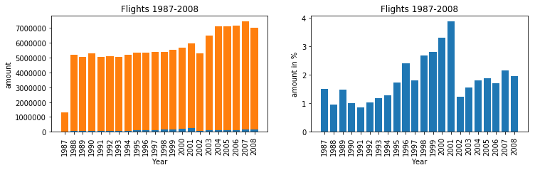

```python
plt.figure(figsize = [12, 3])

plt.subplot(1,2,1)
plt.bar(df_amount.year, df_amount['amount'], color = base_color_2);
plt.bar(df_amount.year, df_amount['cancelled'], color = base_color_1)
ticks = np.arange(1987, 2009, 1)
plt.xticks(ticks, rotation = 90);
plt.title('Flights 1987-2008')
plt.ylabel('amount')
plt.xlabel('Year')

plt.subplot(1,2,2)
plt.bar(df_amount.year, df_amount['cancelled %'], color = base_color_1)
ticks = np.arange(1987, 2009, 1)
plt.ylabel('amount in %')
plt.xlabel('Year')
plt.xticks(ticks, rotation = 90);
plt.title('Flights 1987-2008')
plt.show()
```

#### as we can see general amount of canceled flights is low and the highest amount of cancellation happened in 2001 which is most likely connected to events of 9/11/2001. also, totall amount of flight after decreased but already by 2003 increased again with percentage of cancellations going down

```python
x = df_amount.year
y = df_amount.amount
z = df_amount.cancelled
```

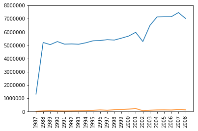

```python
plt.plot(x, y);
plt.plot(x, z);
ticks = np.arange(1987, 2009, 1)
plt.xticks(ticks, rotation = 90);
plt.ylim([0, 8000000]);
```